# Lab 3: HipHop Lyrics

Solutions by Dr. Theobold

## The dataset

The data set “hiphop” contains results from a study conducted by a linguist at the University of Minnesota. The researcher was interested in predicting musical taste based on familiarity with African American English (AAE). 168 subjects participated in the study, and each was asked to define 64 different AAE terms. The definitions given were used to create a “familiarity” score for each subject for each term. This score quantifies how well the subject knew the term on a scale of 1-5 (1 = not at all, 5 = very well). Before tackling the problems, **study the information on the following website**, which includes a description of each variable:

http://conservancy.umn.edu/bitstream/handle/11299/116327/5/explanationAAEHiphopChesley.txt

```r
library(tidyverse)
library(forcats) ## Dr. Theobold's preferred way to work with factors!

hiphop <- read_csv(here::here("3_dplyr", "Lab-hiphop-dplyr", "hiphop.csv"))
```

## Assignment

### Summary

#### 1.

Provide a brief overview (2-4 sentences) of the dataset. (It is always good practice to start an analysis by getting a feel for the data and providing a quick summary for readers.) You do **not** need to show any source code for this question, although you probably want to use code to get information.

**Possible response:**

*This dataset has 10,752 rows and 38 columns, representing responses for each participant to their familiarity with African-American English. These data are the result of a study with 168 undergraduate students who were asked to define AAE terms, as well as some accompanying demographic information. The free response definitions participants gave were turned into five-point Likert scale items reflecting their familiarity with the term (1 = not at all, 5 = well).*

#### 2.

What are the rows of this dataset? It is **not** one person per row!

**Possible response:**

*Every row in the dataset is a word for each participant. When we look at the dataset, we see that the first 168 rows are for the **same** word, but different participants. Thus, we will have 168 rows for each word!*

#### 3.

Missing values for some of the variables were replaced with other values. How were missing values replaced? What do you believe are some benefits and drawbacks of doing this?

**Possible response:**

*Missing values were replaced with mean values for some of the variables in the dataset. This is beneficial, since there are fewer instances of missing data. This is possibly a bad choice if the mean is not representative of what that individual would have responded. For example, if an individual didn’t respond to the question “How many African-Americans do you have contact with on a weekly basis?”, I would be inclined to think their answer might be closer to 0 than to the mean!*

#### 4.

Clean the dataset in whichever ways you see fit. This might mean adjusting *variable type*, for example from “character” to “factor”, or dealing with missing data.

**Possible response:**

```r
hiphop <- hiphop %>%
  mutate(sex = as_factor(sex),
         ethnic = as_factor(ethnic)) %>%
  filter(city > 0)
```

*I chose not to omit any missing values, since there were no missing values for `familiarity`, `sex`, `age`, and `ethnic`. I did, however, choose to remove observations with a city population of 0, since that seemed a bit unreasonable and likely should have been an `NA`.*

#### 5.

How many unique AAE words were studied in this dataset?

```r
hiphop %>%
  distinct(word) %>%
  count()
```

```
## # A tibble: 1 × 1
##       n
##   <int>
## 1    64
```

*There were 64 unique AAVE words included in the study.*

#### 6.

Make a new variable that re-categorizes `ethnic` into only two groups, “white” and “non-white”, to simplify your data.

```r
hiphop <- hiphop %>%
  mutate(
    ethnic_group = if_else(ethnic == "white", "white", "non-white"),
    ethnic_group = as_factor(ethnic_group)
  )
```

**Note:** Personally, I like the `as_factor()` function from the **forcats** package more than the `as.factor()` function. We will learn more about this package and its functions in week 5.

#### 7.

What are the demographics of the people in this study? Investigate the variables `sex`, `age`, and `ethnic` and summarize your findings in 1-3 complete sentences.

```r
subjects <- hiphop %>%
  distinct(subj, .keep_all = TRUE)


subjects %>%
  select(age, sex, ethnic, ethnic_group) %>%
  summary()
```

```
##       age            sex           ethnic       ethnic_group
##  Min.   :16.00   Female:112   white   :134   white    :134
##  1st Qu.:18.00   Male  : 50   asian   : 14   non-white: 28
##  Median :19.00                african :  5
##  Mean   :20.09                hispanic:  3
##  3rd Qu.:20.00                indian  :  2
##  Max.   :48.00                native  :  1
##                               (Other) :  3
```

#### 8.

Make at least two plots to display the demographic information of the subjects in this study. You **do not** need to discuss these plots, but make sure they are appropriate to the data types and have informative titles and axis labels.

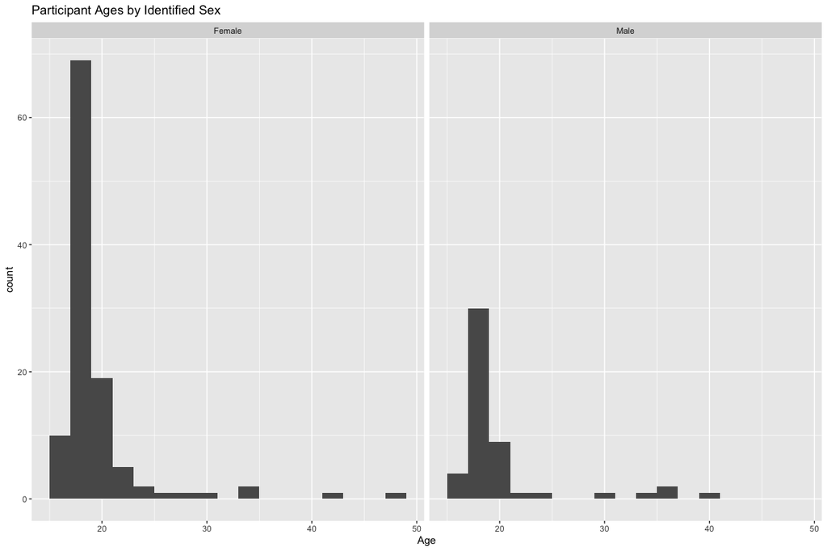

```r
## Many options exist, but I like these:

subjects %>%
  ggplot(aes(x = age)) +
  geom_histogram(binwidth = 2) +
  facet_wrap(~ sex) +
  labs(x = "Age",
       title = "Participant Ages by Identified Sex")
```

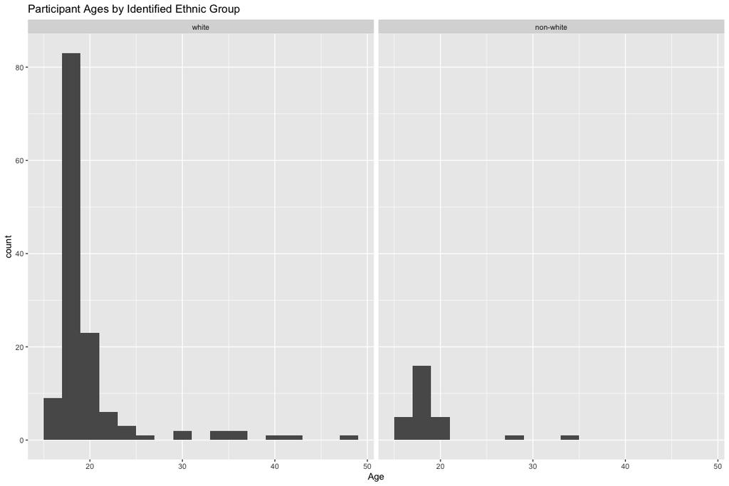

```r
subjects %>%
  ggplot(aes(x = age)) +
  geom_histogram(binwidth = 2) +
  facet_wrap(~ ethnic_group) +
  labs(x = "Age",
       title = "Participant Ages by Identified Ethnic Group")
```

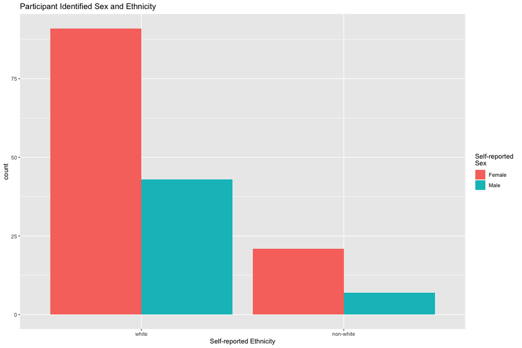

```r
subjects %>%
  ggplot(aes(x = ethnic_group, fill = sex)) +
  geom_bar(position = "dodge") +
  labs(fill = "Self-reported \nSex",
       x = "Self-reported Ethnicity",
       title = "Participant Identified Sex and Ethnicity")
```

### Familiar words

For each demographic group listed below, determine which word(s) in this study was(were) the most **and** least familiar on average.

1. People below the age of 20

```r
young <- hiphop %>%
  filter(age < 20) %>%
  group_by(word) %>%
  summarize(mean_fam = mean(familiarity))
## Although I am generally opposed to taking the mean of Likert data, this gives an "easy" answer

## Most familiar
young %>%
  slice_max(mean_fam) %>%
  pull(word)
```

```
## [1] "off the hook"
```

```r
## Least familiar
young %>%
  slice_min(mean_fam) %>%
  pull(word)
```

```
## [1] "catch the vapors"
```

2. Non-white women

```r
nonwhite_women <- hiphop %>%
  filter(sex == "Female",
         ethnic_group == "non-white") %>%
  group_by(word) %>%
  summarize(mean_fam = mean(familiarity))

# Most familiar
nonwhite_women %>%
  slice_max(mean_fam) %>%
  pull(word)
```

```
## [1] "feel me"
```

```r
## Least familiar
nonwhite_women %>%
  slice_min(mean_fam) %>%
  pull(word)
```

```
## [1] "break someone out" "dukey rope"        "plex"
## [4] "rollie"
```

3. White men above the age of 30

```r
old_white_men <- hiphop %>%
  filter(sex == "Male",
         ethnic_group == "white",
         age > 30) %>%
  group_by(word) %>%
  summarize(mean_fam = mean(familiarity))

## Most familiar
old_white_men %>%
  slice_max(mean_fam) %>%
  pull(word)
```

```
## [1] "5-0"
```

```r
## Least familiar
old_white_men %>%
  slice_min(mean_fam) %>%
  pull(word)
```

```
##  [1] "ay yo trip"        "beezy"             "break someone out"
##  [4] "catch the vapors"  "crossroads"        "crump"
##  [7] "dap"               "dollar cab"        "domino"
## [10] "duckets"           "face gator"        "fetti"
## [13] "finna"             "ghostride"         "good hair"
## [16] "grip grain"        "guap"              "humming"
## [19] "mail"              "plex"              "rollie"
## [22] "saditty"           "sweatbox"          "trill"
## [25] "twurk"
```

### Study Subjects

A joke among the [Tidy Tuesday](https://www.tidytuesday.com/) community is that Justin Bieber was one of the subjects in this study. Bieber, a white male, from a relatively small town (10,000-60,000 people) in Ontario would have been 17-23 at the time of the study.

Determine which subject you believe is secretly Bieber, justify your answer.

*Hint: Refer again to the dataset description. There is another clue about Bieber’s identity.*

```r
hiphop %>%
  distinct(subj, .keep_all = TRUE) %>%
  filter(sex == "Male",
         age <= 23,
         age >= 17,
         city < 60000,
         city > 10000) %>%
  slice_max(bieber) %>%
  select(subj)
```

```
## # A tibble: 1 × 1
##   subj
##   <chr>
## 1 p17
```

*Justin Bieber is subject “p17.”*

## Challenge

### Published Comparisons

*(Turn your challenge in as a separate html file from the lab.)*

In the published article ([You Know What It Is: Learning Words through Listening to Hip-Hop](https://journals.plos.org/plosone/article?id=10.1371/journal.pone.0028248)), the author presents a series of comparisons about the variables which most explain an individual’s familiarity with African American English (AAE).

Let us instead compare the number of artists participants reported liking for each genre. Specifically, you will determine which music genre most differentiates each of the demographic groups provided. That is, which genre had much higher average (mean or median) reported artists in one group than the other.

For each demographic comparison below, determine which music genre most differentiates the groups. That is, which genre had much higher average (mean or median) score in one group than the other.

```r
genres <- hiphop %>%
  select(sex, ethnic_group, age, intl:hiphop)
```

**Male versus Female**

```r
genres %>%
  group_by(sex) %>%
  ## For all of the music genres, find the mean for each sex
  summarize(across(intl:hiphop, mean)) %>%
  ## For all of the music genres, find the difference in the sexes
  summarise(across(intl:hiphop, diff)) %>%
  ## Make the differences all positive to compare magnitudes
  summarise(across(intl:hiphop, abs)) %>%
  which.max()
```

```
## rock
##    5
```

```r
## An alternative approach with one less step...
genres %>%
  group_by(sex) %>%
  ## For all of the music genres, find the mean for each sex
  summarize(across(intl:hiphop, mean)) %>%
  ## For all of the music genres, find the difference in the sexes AND find the absolute values
  summarise(across(intl:hiphop, ~ abs(diff(.x)))) %>%
  which.max()
```

```
## rock
##    5
```

2. White versus Non-White

```r
genres %>%
  group_by(ethnic_group) %>%
  ## For all of the music genres, find the mean for each sex
  summarize(across(intl:hiphop, mean)) %>%
  ## For all of the music genres, find the difference in the sexes
  summarise(across(intl:hiphop, diff)) %>%
  ## Make the differences all positive to compare magnitudes
  summarise(across(intl:hiphop, abs)) %>%
  which.max()
```

```
## rock
##    5
```

### Study Design Critique

The following are criticism of this study from a previous STAT 331 student. I wholeheartedly agree with their sentiment and the concerns they raise.

So basically in my opinion, any linguistic/ psychological/ sociological etc. study that is designed to “study” a trait associated with a minority group is such a gray area, and often seems very othering. Like in this instance, I see a white researcher leading a study that investigates the linguistic patterns of Black people, and it sort of sets off alarm bells and prompts me to think critically about the study design and the end goals of the research (beyond just those that are stated). This is something I see in older political science research on the topic of race, and something I try to be aware of for more current research.

When I first saw this data and read the description, I looked up the researcher and the full study since I felt a lot more context was needed While there isn’t very much information online about the main author Paula Chesley or her racial/ethnic identity, she definitely presents as a white woman. She also is the only author listed on the paper, which is confusing to me since the study is about AAE yet includes no Black/African American researchers. Also, the full name of the study is “You Know What It Is: Learning Words through Listening to Hip-Hop” Given that Chesley is a white academic researching AAE for the underlying purpose of studying vocabulary acquisition, I think it is pretty glib to use a term from AAE as a catchy cutesy title for her paper.